# Lecture 6 - Linear Regression, Multiple Linear Regression, ANOVA, ANCOVA: Choosing the Best Model for the Job

### 2.5.3 Every F-statistic is an *F-value* with an accompanying *p-value*

So from some of the values supplied by `anova()` we can confirm that the calculation of the F value is correct.

**Note**: **F-tests** are not used alone because you still need to use a p-value to find out 'what' is significant. This p-value is part of the **F-statistic** and calculated as follows:

`pf(F-value, Res.df-delta, Res.df1, lower.tail=FALSE)`.

The `pf()` function generates an F-distribution given the supplied degrees of freedom and finds the area under the curve at the upper tail starting at the supplied F-value.

From that calculation we see that `Pr(>F)` is smaller than our $\alpha$ of 0.05.

Put simply, this result suggests that by increasing the complexity of our model to account for BMI, we have succeeded in improving the fit to our data since we already know from above that a higher percent of variance is explained in `ageBMIFit` compared to `ageFit`.

0.000217356184817457

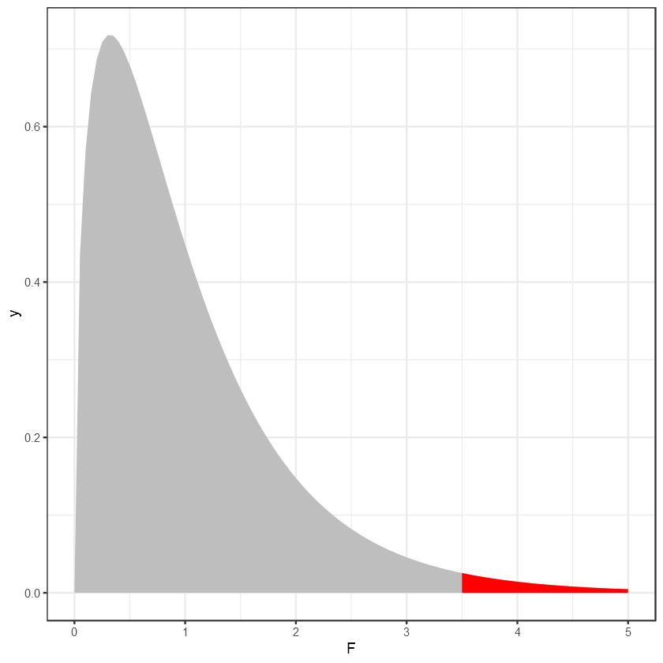

```r
# How to calculate the p-value yourself
pf(13.93079, df1=1, df2=397, lower.tail=FALSE)

# Example F-distribution and area
# 1. Data
ggplot(data.frame(F=c(0,5))) +
    # 2. Aesthetics
    aes(F) +
    theme_bw() +
    # 4. Geoms (using a stat function)
    stat_function(fun = df, geom="area", fill="grey", args=list(df1=3, df2=47)) +
    stat_function(fun = df, geom="area", fill="red", args=list(df1=3, df2=47), xlim=c(3.5, 5))
```

### 2.5.4 Comparing models with `AIC()`

The Akaike Information Criterion (AIC) is a another method for model selection. The AIC works to balance the trade-offs between the complexity of a given model and its goodness of fit (how well the models fits the data), where the **best** model is the one that provides the maximum fit for the fewest predictors. Its interpretation is fairly straight forward: The lower the score, the better a model is **relative** to the other models. If many models have similarly low AICs, you should choose the one with the fewest model terms (variables or parameters).

```r
# compare ageFit and ageBMIFit using AIC()
AIC(ageFit, ageBMIFit)
```

A data.frame: 2 × 2

|  | df <dbl> | AIC <dbl> |
| --- | --- | --- |
| ageFit | 3 | 3600.511 |
| ageBMIFit | 4 | 3588.716 |

Given that `ageBMIFit` has a lower score, we can say that is the best model out of the two evaluated.

## 2.6.0 Adding interaction terms to our model with a `*` or `:`

**What is meant by an interaction?**

There is an **interaction** if the association between the response and the predictor variable changes across the range of the new variable. This can be seen in the expression below, where the difference in means between x<sub>1</sub> and x<sub>2</sub> changes additionally by b<sub>3</sub> for each unit difference in x<sub>2</sub> or x<sub>1</sub>, i.e. the slope of x<sub>1</sub> changes with x<sub>2</sub>, because b<sub>3</sub> is changing.

In our case study, interaction refers to how BMI (the third variable) affects the interaction between cholesterol and age.

*Expression:*

\begin{equation*}\Large Y \sim Normal(a + b_1x_1 + b_2x_2 + b_3x_1x_2, {\sigma^2}) \end{equation*}

| Should you include an additional variable in your model? Identifying interacting variables is important but non-trivial. |
| --- |

When testing for an interaction between 2 input variables, the `lm()` input takes a colon `:` instead of a `+` between the dependent variables. However if you wanted to test your variables `x1`, `x2`, and their interaction `x1:x2` then we substitute the asterisk `*`.

*R code:*

`lm(y ~ x1 * x2)`

**Crossing versus Interactions** While in our above examples we used the * (asterisk) as an operator for interaction it is actually denoted as crossing in our formulas. This means for the formula **y ~ a*b** we are saying that y is a function of a, b and their interaction. Sometimes you may wish to only use an interaction using the colon "**:**" in a formula such as **y ~ a + a:b** which defines y as a function of a and the interaction between a and b **but does not** account for the independent variable b itself.

An interaction is different than a **confounding factor**, for which the association between the response and predictor variable is constant across the range of the new variable. You can think of **confounding factors** as variables that have an effect on the response and predictor, but haven't been accounted for.

For example, in our first model the increase in cholesterol was ONLY due to an increase in `age`. What if we added `BMI` to the model because weight contributes significantly to an increase in cholesterol? In this case, `age` might be a **confounding factor** because increasing `age` might also influence `BMI` meaning our response variable (`chol`) AND another predictor (`BMI`) may be influenced by `age`.

In other words to update our model, we might wish to account for how `age` and `BMI` interact to influence `chol`.

### 2.6.1 Steps for including an interaction term: updating our model of cholesterol prediction

Test if there is an interaction between `age` and `BMI` in a model predicting mean serum cholesterol. Note that these are both continuous variables. Consider the following questions:

1. Is the interaction significant?
2. Is there a difference between this model and the model with age as the only variable?
3. Is there a difference between this model and the model of BMI and age model with no interaction?

How do we go about answering these questions?

Begin by creating a new model to predict cholesterol levels which incorporates `age` and `BMI` as *interacting terms*.

```r
# Build a new model accounting for an interaction between age and BMI
ageIntBMIFit <- lm(chol ~ age * BMI, data = cholesterol)

# summarise the model
summary(ageIntBMIFit)
```

```
Call:
lm(formula = chol ~ age * BMI, data = cholesterol)

Residuals:
    Min      1Q  Median      3Q     Max
-59.207 -15.767   0.379  13.926  62.715

Coefficients:
             Estimate Std. Error t value Pr(>|t|)
(Intercept) 1.450e+02  3.647e+01   3.975 8.37e-05 ***
age         6.085e-02  6.461e-01   0.094    0.925
BMI         1.109e+00  1.489e+00   0.745    0.457
age:BMI     5.694e-03  2.581e-02   0.221    0.826
---
Signif. codes:  0 '***' 0.001 '**' 0.01 '*' 0.05 '.' 0.1 ' ' 1

Residual standard error: 21.37 on 396 degrees of freedom
Multiple R-squared:  0.07362,	Adjusted R-squared:  0.0666
F-statistic: 10.49 on 3 and 396 DF,  p-value: 1.182e-06
```

It appears that the interaction effect `age:BMI` does not appear to be significant. Our R-squared value is also only 0.0666 which suggests that this model explains only 6.6% of the variation in our dataset. Let's follow up by comparing this new model to our previous ones: `ageFit` and `ageBMIFit`.

```r
# Compare to our previous models
# linear vs. interaction
anova(ageFit, ageIntBMIFit)

# multiple linear vs. interaction
anova(ageBMIFit, ageIntBMIFit)

# AIC of all three
AIC(ageFit, ageBMIFit, ageIntBMIFit)
```

A anova: 2 × 6

|  | Res.Df <dbl> | RSS <dbl> | Df <dbl> | Sum of Sq <dbl> | F <dbl> | Pr(>F) <dbl> |
| --- | --- | --- | --- | --- | --- | --- |
| 1 | 398 | 187187.5 | NA | NA | NA | NA |
| 2 | 396 | 180819.5 | 2 | 6367.976 | 6.973028 | 0.001056228 |

A anova: 2 × 6

|  | Res.Df <dbl> | RSS <dbl> | Df <dbl> | Sum of Sq <dbl> | F <dbl> | Pr(>F) <dbl> |
| --- | --- | --- | --- | --- | --- | --- |
| 1 | 397 | 180841.7 | NA | NA | NA | NA |
| 2 | 396 | 180819.5 | 1 | 22.2158 | 0.04865327 | 0.8255372 |

A data.frame: 3 × 2

|  | df <dbl> | AIC <dbl> |
| --- | --- | --- |
| ageFit | 3 | 3600.511 |
| ageBMIFit | 4 | 3588.716 |
| ageIntBMIFit | 5 | 3590.667 |

From our analyses above, the comparison suggest that while better than using `age` alone to estimate cholesterol levels, the `ageBMIFit` model which combines the **independent** effects of `age` and `BMI` is not significantly different versus modeling an interaction between these two variables in our model `ageIntBMIFit`. This is confirmed with the results of the Akaike Information Criterion test as well.

**Comprehension Question 2.0.0:** Going back to our linear models, what if we made a model only looking at the effect of BMI on cholesterol? What is the R-squared value? Compare and contrast this to how much variation is explained by our models **ageFit** and **ageBMIFit**. Use the code cell below to make your calculations

## Comprehension Question 2 Answers:

```r
# What is the R-Squared value of ageFit?
summary(...)

# What is the R-Squared value of ageBMIFit?
summary(...)

# Create a new model of cholesterol using only BMI as a predictor.
# What is it's R-squared value?
bmiFit <- lm(...)

summary(bmiFit)
```

# 3.0.0 Other general linear models for categorical independent variables

| Time to discuss modeling on categorical variables. |
| --- |

Up to now we've been comparing the effect of age and BMI on cholesterol levels but these are *continuous* variables. Remember we have also included haplotypes for three genetic loci in our dataset. How do we build a model analysing the influence of these independent variables on our outcome (cholesterol)?

The suite of general linear models includes many statistical models, which we will continue to discuss in the context of our data. Until now, we have been focused on the subgroup of regression models - in which all of our independent variables are **quantitative**. The remainder of our models, while still being general linear models, include one or more **categorical** independent variables.

Recall our data tracks a number of genetic variants and codes the genotype of observations for each:

| ID | sex | age | chol | BMI | TG | rs174548 | rs4775401 | APOE |
| --- | --- | --- | --- | --- | --- | --- | --- | --- |
| patient code | Male=0 Female=1 | patient age | cholesterol | Body mass index | triglycerides | haplotype C/C = 0 C/G = 1 G/G = 2 | haplotype C/C = 0 C/T = 1 T/T = 2 | allele haplotype e2/e2 = 1 e2/e3 = 2 e2/e4 = 3 e3/e3 = 4 e3/e4 = 5 e4/e4 = 6 |

## 3.1.0 One-way analysis of variance (ANOVA)

In the analysis of variance (ANOVA) all independent variables are **categorical** (factors) rather than continuous. This allows us to ask the question:

**Does the genetic factor *rs174548* have an effect on cholesterol levels?**

Our categorical example is represented by $\alpha$ and $i$ represents the levels of our factor.

*Expression:*

\begin{equation*}\Large Y \sim Normal({\alpha_i}, {\sigma^2}) \end{equation*}

We still use the `lm()` function, however we replace our continuous variable with f, a categorical variable (factor). If your data is character type, R will automatically make a factor for you. **However**, if your data is numeric, R will interpret it as continuous. In this case, you need to make your numeric data a factor first using `factor()`.

*R code:*

`lm(y ~ f)`

R parameterizes the model in terms of the differences between the first group and subsequent groups (ie. relative to the first group) rather than in terms of the mean of each group. This is similar to the interpretation of the previous linear models. You can instead fit the means of each group using: `lm(y ~ f-1)`, similar to how we force the y-intercept to 0.

To begin the journey in answering our question, we first plot the relationship between *rs174548* and *cholesterol*.

```r
# Let us look at the structure of our dataset to again
str(cholesterol)

# First, take a look at the levels of the factor rs174548 using the level() function.
# It's the equivalent to ask for unique() in a character vector
unique(cholesterol$rs174548)

# Get the levels
levels(cholesterol$rs174548)
```

```
'data.frame':	400 obs. of  10 variables:
 $ ID       : int  1 2 3 4 5 6 7 8 9 10 ...
 $ sex      : int  1 1 0 0 1 1 0 0 0 0 ...
 $ age      : int  74 51 64 34 52 39 79 38 52 58 ...
 $ chol     : int  215 204 205 182 175 176 159 169 175 189 ...
 $ BMI      : num  26.2 24.7 24.2 23.8 34.1 22.7 22.9 24.9 20.4 22 ...
 $ TG       : int  367 150 213 111 328 53 274 137 125 209 ...
 $ rs174548 : int  1 2 0 1 0 0 2 1 0 0 ...
 $ rs4775401: int  2 1 1 1 0 2 1 1 1 1 ...
 $ APOE     : int  4 4 4 1 1 4 1 1 4 5 ...
 $ age_group: num  1 0 1 0 0 0 1 0 0 1 ...
```

1. 1

2. 2

3. 0

Why are the levels of our variable `rs174548` set to `NULL`? Looking at the structure we see that this variable is listed as an `int` and is not yet a factor - so no levels exist.

Recall that we can coerce from integers and character variables into factors by casting them directly as we see below. We can do the same with variables, on the fly, as we plot our data into a scatterplot and boxplot.

```r
# Make it a factor and then get its levels
levels(factor(cholesterol$rs174548))
```

1. '0'

2. '1'

3. '2'

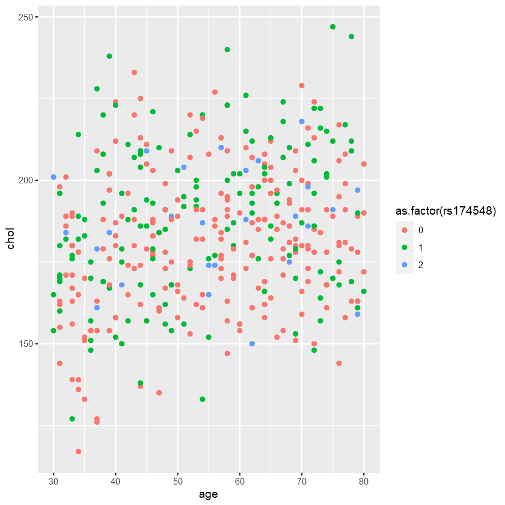

```r
# scatter plot our cholesterol data but colour based on rs174548
# 1. Data
ggplot(cholesterol) +
    # 2. Aesthetics
    aes(x=age, y=chol, colour = as.factor(rs174548)) +
    # Geoms
    geom_point()
```

Hard to see the distribution of our factors right? It looks all very mixed up. Perhaps a boxplot will clarify this data?

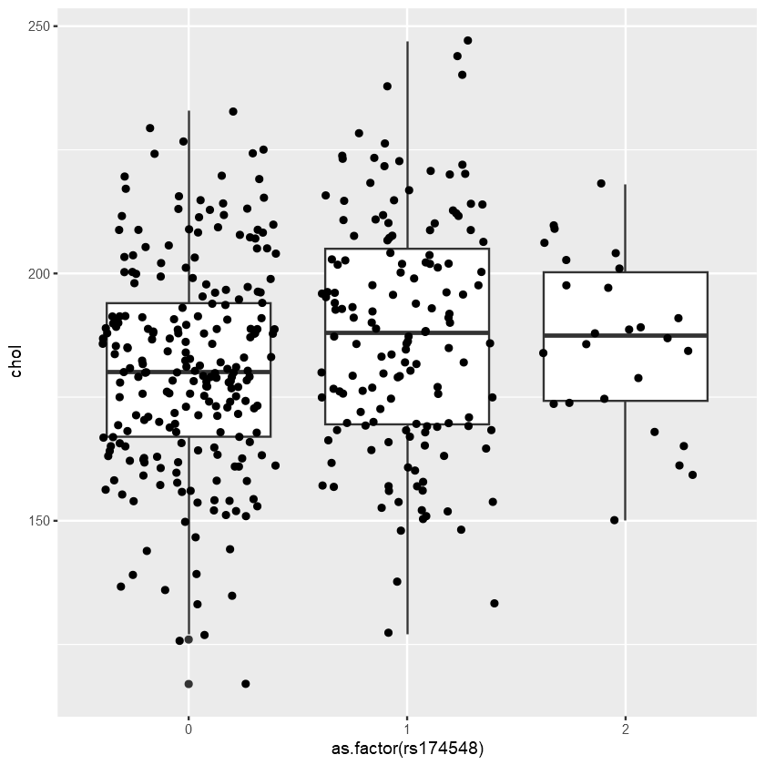

```r
# Make a boxplot of rs174548
# 1. Data
ggplot(cholesterol) +
    # 2. Aesthetics
    aes(x = as.factor(rs174548), y = chol) +
    # 4. Geoms
    geom_boxplot() +
    geom_jitter()
```

From our preliminary plots, we see that our genetic factor has 3 groups, and we will be comparing the means for each of these groups. These groups have high variance, and there is a good deal of overlap between them.

**A reminder about factor() versus as.factor():** We've seen through our code that most data structures or objects can be cast in one of two ways: **object()** or **as.object()**. So which is better for using when we cast objects? Usually the former version is used in the basic construction of an object, when first instantiating it. There are additional steps "under the hood" that are optimized for initializing a data frame or factor.

In the case of **factor()**, this includes going through all of the unique factors, sorting them, and identifying unused levels. On the other hand, **as.factor()** is slightly optimized for conversion of integers and pre-existing factor objects. When casting a factor back to a factor, this will not change the order of your levels!

Looking closely at the documentation will also show that **as.factor()** only takes a single argument - the object for conversion, not setting levels, order, or labels!

### 3.1.1 Basic formulas for calculating One-way ANOVA F-values

\begin{equation*} \begin{aligned} SSR_{i} &=\sum n_{i} (\bar{y}_{i} - \bar{y})^{2} &\text{Deviation of the estimated factor level mean around the overall mean, at factor level } i \text{ with } n_{i} \text{ samples}\\[10pt] SSE &=\sum_{i=1}^{\substack{x factor\\levels}} \sum_{j}^{\substack{m\\obs.}} ({y}_{ij} - \bar{y}_{i})^{2} &\text{Sum of deviation of each observation from its factor level mean}\\[30pt] DF_{Factor} &= \text{factor levels} - 1 &\text{Degrees of freedom for factor component}\\[10pt] DF_{Error} &= \text{total obs.} - \text{factor levels} &\text{Degrees of freedom for the MSE component}\\[30pt] MSR_{i} &= \frac{SSR_{i}}{DF_{Factor}} &\text{The mean square for a factor level } i\\[10pt] MSE &= \frac{SSE}{DF_{Error}} &\text{The mean square error across all samples}\\[30pt] F &= \frac{MSR_{i}}{MSE} &\text{Our final F-value for a given factor level } i \text{ analyzing: } \frac{\text{between-groups variance}}{\text{within-group variance}} \end{aligned} \end{equation*}

**Still, in a nutshell...**

To assess whether the means are equal, the model compares:

- Variation between the sample means (mean square due to regression, MSR, analog to beta-diversity)
- Natural variation of the observations within the sample (mean square error, MSE, analog to alpha-diversity)

[output not shown]

Recall our formulas when comparing between models with `anova()`? You can see it's similar in concept except the numerator and denominator are calculated in relation to the means of each factor level. The larger the **MSR** compared to the **MSE**, the more support there is for a difference between the population means.

So how do we put this to practical use in R?

### 3.1.2 Setting up a one-way ANOVA model for our question

Now that we know more about *how* a one-way ANOVA is calculated, let's talk about how to write the expression to model our categorical variable. The form of this equation should look more familiar.

*Expression:*

\begin{equation*}\Large Y \sim Normal({\beta_0 + \beta_1x_1 + \beta_2x_2}, {\sigma^2}) \end{equation*}

The interpretation of this model is a bit trickier.

- $\beta_0$: mean cholesterol when rs174548 is C/C
- $\beta_0$ + $\beta_1$: mean cholesterol when rs174548 is C/G
- $\beta_0$ + $\beta_2$: mean cholesterol when rs174548 is G/G

Alternatively,

- $\beta_1$ is the difference in mean cholesterol levels between groups with rs174548 equal to C/G (1) and C/C (0)
- $\beta_2$ is the difference in mean cholesterol levels between groups with rs174548 equal to G/G (2) and C/C (0)

So you can think of each of these groups having their own means, i.e. $\mu_0 = \beta_0$, $\mu_1 = \beta_0 + \beta_1$, $\mu_2 = \beta_0 + \beta_2$. We are testing the hypothesis that not all of these means are equal.

### 3.1.3 Behind the curtain, your categorical factor is a dummy variable

Before jumping into the ANOVA, we should consider some ways to help make our analysis simpler. For instance, we can encode our categorical variable as a *dummy* or *treatment* variable. In our data frame for the rs174548 variable, 0 stands for the genotype C/C, 1 is C/G and 2 is G/G. Therefore, there are $k$ factor levels to our categorical variable. Using this information, we can create a matrix with $k-1$ separate columns of 0s and 1s to represent our levels and we will *contrast* each to the reference level (C/C). A genotype will be compared to the reference genotype if it has a 1, and so all comparisons to the reference are included in the matrix.

| rs174548 | x1 | x2 |
| --- | --- | --- |
| C/C | 0 | 0 |
| C/G | 1 | 0 |
| G/G | 0 | 1 |

**Luckily for us**, R will automatically create dummy variables in the background if you state you have a categorical variable.

Recall that ANOVA is also based on testing hypotheses. It will use the F-value and degrees of freedom from our model to ascertain which of the following hypotheses we should accept/reject.

1. $H_0$ (null hypothesis): there is no difference between group means
2. $H_a$ (alternate hypothesis): there is a difference between group means

Also, there are technically **2** ways for us to do this analysis!

### 3.1.4 One-way ANOVA using `lm()` and `summary()`

As before, we can build our linear model with `lm()` and then generate summary statistics for it. This will give us some helpful information about the model in understanding or interpreting it's information.

```r
# Create a one-way anova model by converting rs174548 to a factor
# Note that R will create the dummmy variable for us
rs174548Fit <- lm(chol ~ as.factor(rs174548), data = cholesterol) # C/C, represented by 0, is our reference variable (intercept)

# Retrieve a summary of our model
summary(rs174548Fit)
```

```
Call:
lm(formula = chol ~ as.factor(rs174548), data = cholesterol)

Residuals:
    Min      1Q  Median      3Q     Max
-64.062 -15.913  -0.062  14.938  59.136

Coefficients:
                     Estimate Std. Error t value Pr(>|t|)
(Intercept)           181.062      1.455 124.411  < 2e-16 ***
as.factor(rs174548)1    6.802      2.321   2.930  0.00358 **
as.factor(rs174548)2    5.438      4.540   1.198  0.23167
---
Signif. codes:  0 '***' 0.001 '**' 0.01 '*' 0.05 '.' 0.1 ' ' 1

Residual standard error: 21.93 on 397 degrees of freedom
Multiple R-squared:  0.0221,	Adjusted R-squared:  0.01718
F-statistic: 4.487 on 2 and 397 DF,  p-value: 0.01184
```

### 3.1.4.1 Interpretation of the model and statistics

Under our `Coefficients` table we see that the individula p-values for seeing the cholesterol values in a specific haplotype given that the $H_0$ is true. Haplotype 0 is folded into the intercept.

- The intercept, 181.06 mg/dl, is the mean cholesterol when rs174548 is C/C (0).
- 181.06 mg/dl + 6.80 mg/dl is the mean cholesterol when rs174548 is C/G (1).
- 181.06 mg/dl + 5.44 mg/dl is the mean cholesterol when rs174548 is G/G (2).

Alternatively,

- 6.80 mg/dl is the difference in mean cholesterol levels between groups with rs174548 equal to C/G (1) and C/C (0)
- 5.44 mg/dl is the difference in mean cholesterol levels between groups with rs174548 equal to G/G (2) and C/C (0)

The summary tells us that the genetic factor *rs174548* has an effect on cholesterol at a significance level of p = 0.01184 (< 0.05). Looking closely at the Adjusted R-squared value, we also see that this independent variable accounts for only 1.718% of variability in our cholesterol data.

An analysis of variance table from calling `anova()` with one model as input gives us the same F-value and p-value.

```r
# anova() returns only significant differences in the model
anova(rs174548Fit)
```

A anova: 2 × 5

|  | Df <int> | Sum Sq <dbl> | Mean Sq <dbl> | F value <dbl> | Pr(>F) <dbl> |
| --- | --- | --- | --- | --- | --- |
| as.factor(rs174548) | 2 | 4314.195 | 2157.0973 | 4.486538 | 0.01183627 |
| Residuals | 397 | 190874.915 | 480.7932 | NA | NA |

As you can see, we were able to retrieve the same information about the overall model showing that *rs174548* genotype is a contributing factor to cholesterol values.

### 3.1.5 Use `aov()` and `summary()` to analyse our model

With the simple models we are generating, there is little advantage to using `aov()` over `lm()`. Both are from the base `stats` package and in reality, `aov()` calls on the `lm()` function behind the scenes. However, for more complicated models involving multiple factors and interactions, the summary output for `aov()` is better and it can also support error terms in your model.

So, leave this as an additional option to explore when generating more complex models.

```r
# An equivalent command would be using aov()
summary(aov(chol~ as.factor(rs174548), data=cholesterol))
```

```
                     Df Sum Sq Mean Sq F value Pr(>F)
as.factor(rs174548)   2   4314  2157.1   4.487 0.0118 *
Residuals           397 190875   480.8
---
Signif. codes:  0 '***' 0.001 '**' 0.01 '*' 0.05 '.' 0.1 ' ' 1
```

### 3.1.6 Your ANOVA only indicates if at least one population mean is significantly different!

Notice that the *p-value* for the whole set of comparisons is 0.01184 against our $H_0$ of the predictor, *rs174585*, having no relationship with the response variable of *cholesterol*. We must consider what this **really** means for the model we gave to `lm`.

The ANOVA and it's variants are considered **omnibus** test which are technically just exploratory analysis. The omnibus analyses can tell us that there is a difference in means (rejects the null hypothesis that all means are the same), but they **does not** tell us which population/group means are significantly different from one another.

In order to look at this we need to look at multiple pairwise comparisons of

$$\mu_0 = \mu_1,\;\;\; \mu_0 = \mu_2,\;\;\; \mu_1 = \mu_2$$

**Omnibus results are dependent on your model!** After being sure you can run an omnibus test on your dataset, you can finally run it. This *exploratory* test, however, is designed to test if the **explained variance** in your dataset (ie your data grouped by membership in your independent variables from your model) is significantly greater than the **unexplained variance** overall (everything that remains of the total variance after adjusting for your model's independent variables).  
More importantly, it is *very important to choose your model carefully*. The inclusion of unnecessary independent variables can push the effect of significant variables in your model over into insignicance. Thus although your omnibus returns a negative result, *part of your model* [may still significantly contribute to the variation in your data!](https://en.wikipedia.org/wiki/Omnibus_test)

## 3.2.0 Post-Hoc or Post-ANOVA tests with (multiple) test correction

*Post-Hoc* in Latin, means "after this", referring to analyses done after an ANOVA, with the objective of identifying which means, **if any**, show significant differences from each other.

Multiple comparisons increase the **family-wise error rate (FWER)** - the probability of making a **false discovery** (a.k.a. a **false positive** or **Type I error**). This is where multiple test corrections come in to control the error at a specific threshold, i.e. $\alpha = 0.05$ or 5%. One of the simplest and most conservative tests is the Bonferroni correction ($\alpha/k$ or multiplying p-values by $k$).

**Remember**: $k$ is the number of factor levels in our categorical variable. ie $k = 3$ for *rs174585*

To run multiple tests to see if group means differ we can use this equation for **general linear hypothesis testing**, which takes two objects:

1. a model
2. a contrast matrix

We'll start by remaking our model with a slight change to obtain the absolute mean of each group rather than the relative mean. Previously, it was mentioned that you can fit the means for each group using `lm(y ~ f-1)`.

```r
# test the fit of our model
rs174548TestFit <- lm(chol ~ as.factor(rs174548) -1, data = cholesterol) # -1 drops the intercept
summary(rs174548TestFit)
```

```
Call:
lm(formula = chol ~ as.factor(rs174548) - 1, data = cholesterol)

Residuals:
    Min      1Q  Median      3Q     Max
-64.062 -15.913  -0.062  14.938  59.136

Coefficients:
                     Estimate Std. Error t value Pr(>|t|)
as.factor(rs174548)0  181.062      1.455  124.41   <2e-16 ***
as.factor(rs174548)1  187.864      1.809  103.88   <2e-16 ***
as.factor(rs174548)2  186.500      4.300   43.37   <2e-16 ***
---
Signif. codes:  0 '***' 0.001 '**' 0.01 '*' 0.05 '.' 0.1 ' ' 1

Residual standard error: 21.93 on 397 degrees of freedom
Multiple R-squared:  0.9861,	Adjusted R-squared:  0.986
F-statistic:  9383 on 3 and 397 DF,  p-value: < 2.2e-16
```

### 3.2.1 Build a contrast matrix with `contrMat()`

For the second object needed in our group comparisons, we want to make a contrast matrix. The simplest contrast matrix is a matrix of 0, 1, and -1's, where the relationship -1 and 1 are the factor levels that you want to test for differences. Notice that the total of each row is 0.

The `contrMat()` function takes the parameters:

- `n`: an vector of sample sizes for each group. This can be a names or unnamed vector.
- `type`: The type of contrast you want to use (based on the test) ie Dunnett or Tukey, etc.
- `base`: the baseline group to be used for the Dunnett test.

```r
# A contrMat is a one degree of freedom test comparing means.
# It can compare more than two means if you group them in such way that at the end,
# there are only two groups being compared: average of the means of groups 1 and 2 versus the mean of group 3

M <- contrMat(table(cholesterol$rs174548),  # Make a frequency table of the data
              type = "Tukey")               # tukey is a single-step multi pair-wise comparison test to find differences in means

M

# Notice the attributes of our Contrast matrix
print("Structure of M")
str(M)
```

A contrMat: 3 × 3 of type dbl

|  | 0 | 1 | 2 |
| --- | --- | --- | --- |
| 1 - 0 | -1 | 1 | 0 |
| 2 - 0 | -1 | 0 | 1 |
| 2 - 1 | 0 | -1 | 1 |

```
[1] "Structure of M"
 'contrMat' num [1:3, 1:3] -1 -1 0 1 0 -1 0 1 1
 - attr(*, "dimnames")=List of 2
  ..$ : chr [1:3] "1 - 0" "2 - 0" "2 - 1"
  ..$ : chr [1:3] "0" "1" "2"
 - attr(*, "type")= chr "Tukey"
```

### 3.2.2 General linear hypothesis testing with `glht()`

The rownames of the contrast matrix tell us what is being compared ([1-0], [2-0], [2-1]). For example [1-0] is the difference between C/C (-1) and C/G (1).

More complicated comparisons can be made. For example, the difference between C/C and the means of the G/G and C/G populations could be specified by adding a row to the matrix of -2 1 1 (Note: rows of a contrast matrix must add to zero).

To get estimates using general linear hypothesis testing, we use the aptly named `glht()` function with our linear hypotheses to be compared as specified by our contrast matrix. The function will take in our ANOVA model and produce the summary information used to compare each combination of model variables (group means) put forth in our contrast matrix. Overall this takes the work out of creating our own series of comparisons.

We will first look at a summary without adjusting/correcting our p-values.

```r
# library(multcomp)
# multiple comparisons made with our parametric model
mc <- glht(rs174548TestFit, linfct = M)

# Retrieve the summary of our glht object
summary(mc, test = adjusted("none")) # test is a function for computing p values.
```

```
	 Simultaneous Tests for General Linear Hypotheses

Multiple Comparisons of Means: Tukey Contrasts


Fit: lm(formula = chol ~ as.factor(rs174548) - 1, data = cholesterol)

Linear Hypotheses:
           Estimate Std. Error t value Pr(>|t|)
1 - 0 == 0    6.802      2.321   2.930  0.00358 **
2 - 0 == 0    5.438      4.540   1.198  0.23167
2 - 1 == 0   -1.364      4.665  -0.292  0.77015
---
Signif. codes:  0 '***' 0.001 '**' 0.01 '*' 0.05 '.' 0.1 ' ' 1
(Adjusted p values reported -- none method)
```

### 3.2.3 Interpretation of our testing

**[1 - 0 == 0]** The difference in means between C/C and C/G is 6.80 mg/dl and this difference **is** significant.  
**[2 - 0 == 0]** The difference in means between C/C and G/G is 5.44 mg/dl and this difference **is not** significant.  
**[2 - 1 == 0]** The difference in means between C/G and G/G is -1.36 mg/dl and this difference **is not** significant.

You may notice that some of these p-values look familiar from our original `summary()` of the model. We have, however, added the comparison of the C/G to G/G genotypes.

### 3.2.4 Correction for multiple testing

Don't forget we've tested **3** different pairings and need to account for the possibility of false positives.

### But Why?

[output not shown]

**Remember**: if we have set an $\alpha$ level of 0.05, then we may encounter an uncharacteristic result to our $H_0$ by chance once every 20 tests.

**Two general procedures to control error rates:** While we won't go over all of the ways to control for error, recall that there are two main types of errors we are usually concerned with.

1. Type-I error is the false rejection of the null hypothesis aka false-positives
2. Type-II error is the false acceptance of the null hypothesis aka false-negatives.

Depending on the nature of your data, and how many tests you've completed you want to perform some kind of correction on your results. Two popular procedures for correcting type errors are the **Bonferroni correction** and **Benjamini-Hochberg**. The former strictly penalizes all p-values equally, thus controlling for Type-I error but perhaps introducing some more Type-II error - overall erring on the side of caution. The latter penalizes your p-values based on their ranking, attempting to control the proportion of wrongly rejected null hypotheses (False Discovery Rate) within the group of all rejected null hypotheses rather than the whole set of p-values supplied.

Let's check if multiple test correction affects these relationships.

```r
# Adjust the p-values by Bonferroni
# Bonferroni corrects by testing each individual hypothesis at a significance level of α/m,
# where α is the desired overall alpha level and m is the number of hypotheses
summary(mc, test = adjusted("bonferroni"))
```

```
	 Simultaneous Tests for General Linear Hypotheses

Multiple Comparisons of Means: Tukey Contrasts


Fit: lm(formula = chol ~ as.factor(rs174548) - 1, data = cholesterol)

Linear Hypotheses:
           Estimate Std. Error t value Pr(>|t|)
1 - 0 == 0    6.802      2.321   2.930   0.0107 *
2 - 0 == 0    5.438      4.540   1.198   0.6950
2 - 1 == 0   -1.364      4.665  -0.292   1.0000
---
Signif. codes:  0 '***' 0.001 '**' 0.01 '*' 0.05 '.' 0.1 ' ' 1
(Adjusted p values reported -- bonferroni method)
```

```r
# Control for the false discovery rate (FDR)
summary(mc, test = adjusted("BH")) # Benjamini & Hochberg
summary(mc, test = adjusted("fdr")) # alias for BH
```

```
	 Simultaneous Tests for General Linear Hypotheses

Multiple Comparisons of Means: Tukey Contrasts


Fit: lm(formula = chol ~ as.factor(rs174548) - 1, data = cholesterol)

Linear Hypotheses:
           Estimate Std. Error t value Pr(>|t|)
1 - 0 == 0    6.802      2.321   2.930   0.0107 *
2 - 0 == 0    5.438      4.540   1.198   0.3475
2 - 1 == 0   -1.364      4.665  -0.292   0.7702
---
Signif. codes:  0 '***' 0.001 '**' 0.01 '*' 0.05 '.' 0.1 ' ' 1
(Adjusted p values reported -- BH method)
```

```
	 Simultaneous Tests for General Linear Hypotheses

Multiple Comparisons of Means: Tukey Contrasts


Fit: lm(formula = chol ~ as.factor(rs174548) - 1, data = cholesterol)

Linear Hypotheses:
           Estimate Std. Error t value Pr(>|t|)
1 - 0 == 0    6.802      2.321   2.930   0.0107 *
2 - 0 == 0    5.438      4.540   1.198   0.3475
2 - 1 == 0   -1.364      4.665  -0.292   0.7702
---
Signif. codes:  0 '***' 0.001 '**' 0.01 '*' 0.05 '.' 0.1 ' ' 1
(Adjusted p values reported -- fdr method)
```

## 3.3.0 Use multi-way analysis of variance (ANOVA) for two or more categorical variables

What if we use two or more categorical variables (factors) to model our outcome? We can now ask the question:

**Does the effect of the genetic factor rs174548 differ between males and females?**

We need to test whether there is an effect of our factors on cholesterol and also if there is an interaction between these factors.

*Expression:*

\begin{equation*}\Large Y \sim Normal({\alpha_i} + {\beta_j}, {\sigma^2}) \end{equation*}

$\alpha$ and $\beta$ are our categorical variables where $i$ is the level of the first group, and $j$ is the level of the second group. As with one-way ANOVA, R models our categorical variables as factors.

*R code:*

`lm(y ~ factor1 + factor2)`: testing for main effects without interaction.  
`lm(y ~ factor1 * factor2)`: testing for the main effects with interaction.

| Remember when incorporating variables, that they could be interacting or completely independent. |
| --- |

### 3.3.1 Two-way ANOVA *without* interaction using `lm()` or `aov()`

Let's begin looking at our dependent variable cholesterol by assuming there is no interaction between **sex** and the allele **rs174548**. We have two options at this point to consider: do we use `lm()` or `aov()`? Let's compare the summary output from each.

```r
# Two-way factor model with no interaction
sex_rs174548Fit <- lm(chol ~ as.factor(sex) + as.factor(rs174548), data = cholesterol)

summary(sex_rs174548Fit)

# We have two r(rs174548) 1 and 2, because we have 3 levels in that factor. Sex only has two, so only 1 comparison is shown
```

```
Call:
lm(formula = chol ~ as.factor(sex) + as.factor(rs174548), data = cholesterol)

Residuals:
    Min      1Q  Median      3Q     Max
-66.653 -14.463  -0.601  15.445  57.635

Coefficients:
                     Estimate Std. Error t value Pr(>|t|)
(Intercept)           175.365      1.786  98.208  < 2e-16 ***
as.factor(sex)1        11.053      2.126   5.199 3.22e-07 ***
as.factor(rs174548)1    7.236      2.250   3.215  0.00141 **
as.factor(rs174548)2    5.184      4.398   1.179  0.23928
---
Signif. codes:  0 '***' 0.001 '**' 0.01 '*' 0.05 '.' 0.1 ' ' 1

Residual standard error: 21.24 on 396 degrees of freedom
Multiple R-squared:  0.08458,	Adjusted R-squared:  0.07764
F-statistic:  12.2 on 3 and 396 DF,  p-value: 1.196e-07
```

```r
# Use aov to generate our linear model
sex_rs174548Fit_aov <- aov(chol ~ as.factor(sex) + as.factor(rs174548), data = cholesterol)

# Look at a summary of the model
summary(sex_rs174548Fit_aov)
```

```
                     Df Sum Sq Mean Sq F value   Pr(>F)
as.factor(sex)        1  11709   11709  25.951 5.43e-07 ***
as.factor(rs174548)   2   4799    2400   5.318  0.00526 **
Residuals           396 178681     451
---
Signif. codes:  0 '***' 0.001 '**' 0.01 '*' 0.05 '.' 0.1 ' ' 1
```

### 3.3.1.1 `lm()` t-test summaries versus `aov()` anova tables

Looking closely at the summary we see there are two different outputs. The `summary()` of each object produces a slightly different format and result. The `lm()` summary has provided a series of t-test information looking at the levels of each factor, and how each level influences the value of cholesterol with respect to the baseline mean. Each level is also accompanied by a corresponding p-value as we've seen, and overall the model contains an adjusted R-squared value.

The `aov()` summary model on the other hand has less but also different information. Instead it notes the p-values of each factor as a whole, giving us an idea if the term itself is significant to our model. If you were working with many independent variables, you may be more concerned with discerning which ones actually influence the overall variance in your dataset. Note also, the p-values of the `sex` variable in our two models. Why are they different?

Remember that **both** of these functions produces an object that contains all of the information for our model. What we need, however, is a way to summarize that information correctly.

**Multiple Interaction terms:** If we had time to dig deep into these two functions we would find that the most important difference, output aside, is that **lm()** cannot handle creating a model with multiple interaction terms. It can handle a *single interaction term*, but models with *multiple interaction terms* are best left to **aov()**.

### 3.3.2 Use `Anova()` to interpret your results as an ANOVA table

Regardless of which function you use to generate your models you can generate summary ANOVA tables of each model using the `cars::Anova()` function. Yes, R does include an `anova()` function in the base package too! Just be careful in which one you decide to use as the former uses Type-III sum of squares to incorporate error terms while the latter uses Type-I.

**Type-I or Type-III sum of squares?** Whats the big difference between these two approaches and why should you care? Overall for simple models, the difference may not be apparent. It really all depends on how the alogrithm portions our error from each independent variable (factor) from your ANOVA.  
*Type-I* is sensitive to *factor order* in your equation since it attributes overlapping SS error to specific factors. This is implemented in both **aov()** and **anova()**  
*Type-III* on the other hand, is more conservative and leaves potential overlapping SS error out of the analysis but will not be affected by how you order your factors in your equation. This is implemented in both **lm()** and **car::Anova()**

For some extra reading on the topic, you can check out these [helpful](https://towardsdatascience.com/one-of-the-most-common-unintentional-mistakes-when-running-an-anova-in-r-cfa55d332a) [sites](https://stats.stackexchange.com/questions/20452/how-to-interpret-type-i-type-ii-and-type-iii-anova-and-manova/20455#20455).

```r
# Generate an ANOVA table for both models
anova(sex_rs174548Fit_aov) # Calculate SS with Type-I error

Anova(sex_rs174548Fit_aov) # Calculate SS with Type-III error
```

A anova: 3 × 5

|  | Df <int> | Sum Sq <dbl> | Mean Sq <dbl> | F value <dbl> | Pr(>F) <dbl> |
| --- | --- | --- | --- | --- | --- |
| as.factor(sex) | 1 | 11709.372 | 11709.3722 | 25.950839 | 5.430902e-07 |
| as.factor(rs174548) | 2 | 4799.139 | 2399.5697 | 5.318035 | 5.258707e-03 |
| Residuals | 396 | 178680.598 | 451.2136 | NA | NA |

A anova: 3 × 4

|  | Sum Sq <dbl> | Df <dbl> | F value <dbl> | Pr(>F) <dbl> |
| --- | --- | --- | --- | --- |
| as.factor(sex) | 12194.317 | 1 | 27.025595 | 3.224243e-07 |
| as.factor(rs174548) | 4799.139 | 2 | 5.318035 | 5.258707e-03 |
| Residuals | 178680.598 | 396 | NA | NA |

As you can see, there are slightly different results in terms of calculating the sum of squares error between the two ANOVA methods. This also results in different p-values for the independent variable of `sex`. Again, if we were working with many more potential independent variables, we might see more of an impact between the two SS types as well.

### 3.3.3 Interpreting a two-way ANOVA *without* interaction

Going back to the results of our `lm()` call:

-The estimated mean cholesterol for males in C/C group is the intercept, 175.36 mg/dl.  
-The estimated difference in mean cholesterol between females and males controlled for genotype is 11.05 mg/dl.  
-The estimated difference in mean between C/G and C/C groups controlled for sex is 7.24 mg/dl.  
-The estimated difference in mean between G/G and C/C groups controlled for sex is 5.18 mg/dl.

There is evidence cholesterol level is associated with our *rs174548* locus and sex (**p = 1.196<sup>-7</sup>**). This combined model also appears to explain more variability in the data than with just *rs174548* (**7.7% vs. 1.7%**).

How does this compare to the model with sex alone as a predictor? Recall that in the case of **comparing** models, we should use the `anova()` function.

```r
# Build a linear model based on the "sex" variable
sexFit <- lm(chol ~ as.factor(sex), data = cholesterol)
summary(sexFit)
```

```
Call:
lm(formula = chol ~ as.factor(sex), data = cholesterol)

Residuals:
    Min      1Q  Median      3Q     Max
-62.299 -14.343  -0.888  14.701  57.701

Coefficients:
                Estimate Std. Error t value Pr(>|t|)
(Intercept)      178.477      1.522  117.26  < 2e-16 ***
as.factor(sex)1   10.821      2.147    5.04 7.09e-07 ***
---
Signif. codes:  0 '***' 0.001 '**' 0.01 '*' 0.05 '.' 0.1 ' ' 1

Residual standard error: 21.47 on 398 degrees of freedom
Multiple R-squared:  0.05999,	Adjusted R-squared:  0.05763
F-statistic:  25.4 on 1 and 398 DF,  p-value: 7.087e-07
```

```r
# Compare the two models with anova(), NOT Anova()
anova(sexFit, sex_rs174548Fit)
```

A anova: 2 × 6

|  | Res.Df <dbl> | RSS <dbl> | Df <dbl> | Sum of Sq <dbl> | F <dbl> | Pr(>F) <dbl> |
| --- | --- | --- | --- | --- | --- | --- |
| 1 | 398 | 183479.7 | NA | NA | NA | NA |
| 2 | 396 | 178680.6 | 2 | 4799.139 | 5.318035 | 0.005258707 |

In conclusion, our combined non-interacting model explains more variability in our response variable vs looking at `sex` or `rs174548` alone and while `sex` alone explains a good deal of variability, the combined model of both variables is still significantly different.

| Don't forget you should always check to see if your variables are interacting! |
| --- |

### 3.3.4 Build our two-way ANOVA model *with* interaction

While we have concluded there is a difference between our two main ANOVA models, we have to address the possibility that there may be an interaction between our predictor variables of `sex` and `rs174548` in our model. Therefore we should check the two-way ANOVA model with the interaction.

```r
# Build an interaction model with two factors with aov()
sexInt_rs174548Fit_aov <- aov(chol ~ as.factor(sex) * as.factor(rs174548), data = cholesterol)

summary(sexInt_rs174548Fit_aov)

# Look at the Type-III SS summary
Anova(sexInt_rs174548Fit_aov)
```

```
                                    Df Sum Sq Mean Sq F value   Pr(>F)
as.factor(sex)                       1  11709   11709  26.378 4.42e-07 ***
as.factor(rs174548)                  2   4799    2400   5.405  0.00483 **
as.factor(sex):as.factor(rs174548)   2   3779    1889   4.256  0.01483 *
Residuals                          394 174902     444
---
Signif. codes:  0 '***' 0.001 '**' 0.01 '*' 0.05 '.' 0.1 ' ' 1
```

A anova: 4 × 4

|  | Sum Sq <dbl> | Df <dbl> | F value <dbl> | Pr(>F) <dbl> |
| --- | --- | --- | --- | --- |
| as.factor(sex) | 12194.317 | 1 | 27.470072 | 2.606525e-07 |
| as.factor(rs174548) | 4799.139 | 2 | 5.405498 | 4.831173e-03 |
| as.factor(sex):as.factor(rs174548) | 3778.947 | 2 | 4.256407 | 1.483039e-02 |
| Residuals | 174901.651 | 394 | NA | NA |

### 3.3.5 Interpreting our `cars::Anova` model

According to our `Anova()` table of the model, it does appear that there is a statistically significant interaction between `sex` and `rs174548`. If we are interested in the specific interaction, we can take a closer look with `lm()` in this case since we are only using a single interaction term in our model.

```r
# Build an interaction model with two factors with lm()
sexInt_rs174548Fit_lm <- lm(chol ~ as.factor(sex) * as.factor(rs174548), data = cholesterol)

summary(sexInt_rs174548Fit_lm)
```

```
Call:
lm(formula = chol ~ as.factor(sex) * as.factor(rs174548), data = cholesterol)

Residuals:
    Min      1Q  Median      3Q     Max
-70.529 -13.604  -0.974  14.171  54.882

Coefficients:
                                     Estimate Std. Error t value Pr(>|t|)
(Intercept)                          178.1182     2.0089  88.666  < 2e-16 ***
as.factor(sex)1                        5.7109     2.7982   2.041  0.04192 *
as.factor(rs174548)1                   0.9597     3.1306   0.307  0.75933
as.factor(rs174548)2                  -0.2015     6.4053  -0.031  0.97492
as.factor(sex)1:as.factor(rs174548)1  12.7398     4.4650   2.853  0.00456 **
as.factor(sex)1:as.factor(rs174548)2  10.2296     8.7482   1.169  0.24297
---
Signif. codes:  0 '***' 0.001 '**' 0.01 '*' 0.05 '.' 0.1 ' ' 1

Residual standard error: 21.07 on 394 degrees of freedom
Multiple R-squared:  0.1039,	Adjusted R-squared:  0.09257
F-statistic:  9.14 on 5 and 394 DF,  p-value: 3.062e-08
```

### 3.3.5.1 Interpreting a two-way ANOVA *with* interaction

Breaking down the information from our coefficients, we can summarize based on the `sex` and `rs174548` genotype as follows:

| sex | rs174548 | estimated mean cholesterol (mg/dl) | p-value |
| --- | --- | --- | --- |
| M | C/C | 178.12 |  |
| F | C/C | 178.12 + 5.71 | 0.04192 |
| M | C/G | 178.12 + 0.96 | 0.75933 |
| M | G/G | 178.12 - 0.20 | 0.97492 |
| F | C/G | 178.12 + 5.71 + 0.96 + 12.74 | 0.00456 |
| F | G/G | 178.12 + 5.71 - 0.20 + 10.22 | 0.24297 |

There appears to be a significant interaction between being female and having the C/G genotype (p<0.01) but which groups does this apply to? Our omnibus overall p-value also tells use that there is a significant difference between the group means within our model (p = 3.062<sup>-8</sup>)

First let's compare the 2 two-way ANOVA models we've generated that look at **sex** and **rs174548** with and without interaction.

```r
# anova to compare the 2 models of two-way ANOVA
anova(sex_rs174548Fit, sexInt_rs174548Fit_aov)
```

A anova: 2 × 6

|  | Res.Df <dbl> | RSS <dbl> | Df <dbl> | Sum of Sq <dbl> | F <dbl> | Pr(>F) <dbl> |
| --- | --- | --- | --- | --- | --- | --- |
| 1 | 396 | 178680.6 | NA | NA | NA | NA |
| 2 | 394 | 174901.7 | 2 | 3778.947 | 4.256407 | 0.01483039 |

There is evidence that these two models are different (p = 0.01483). Let's compare all three models as a last step with `AIC()`.

```r
# Use AIC to help compare all three models we've generated
AIC(sexFit, sex_rs174548Fit, sexInt_rs174548Fit_aov)
```

A data.frame: 3 × 2

|  | df <dbl> | AIC <dbl> |
| --- | --- | --- |
| sexFit | 3 | 3592.509 |
| sex_rs174548Fit | 5 | 3585.907 |
| sexInt_rs174548Fit_aov | 7 | 3581.357 |

### 3.3.6 Review the models and investigate further with `TukeyHSD()`

We've generated 3 models to explain our cholesterol values in terms of **sex** and the genetic locus **rs174548**.

| Independent variables | Model | term relationship | Adjusted R-squared | F-value | p-value | AIC |
| --- | --- | --- | --- | --- | --- | --- |
| sex | One-way ANOVA | NA | 0.05763 | 25.4 | 7.087e-07 | 3592.509 |
| sex, rs174548 | Two-way ANOVA | additive | 0.07764 | 12.2 | 1.196e-07 | 3585.907 |
| sex, rs174548 | Two-way ANOVA | interacting | 0.09257 | 9.14 | 3.062e-08 | 3581.357 |

It looks like our third model that accounts for interaction between sex and *rs174548* explains the most variation. To investigate the story further we would want to look at which interactions are possibly the most significant.

**Is your ANOVA design balanced?** While we haven't directly addressed our data, you should try to keep in mind that a balanced design will have the same number of observations for **all possible level combinations**. This is easier to accomplish when you are looking at a single factors and its levels. When you start using multiple factors and levels, the number of combinations begins to quickly increase!

Since we already have an ANOVA model and wish to make multiple comparisons, we can use the `TukeyHSD()` function (Tukey's Honestly Significant Differences) to identify which levels may interact across the factors in our model. This function works best on a balanced design **but** can adjust for mildly unbalanced designed as well.

The procedure creates a critical value based on your design and desired $\alpha$ level so the result **already takes into account the multiple comparisons** generated to provide an adjusted p-value. To recap, we'll need:

- An `aov` model object.
- A balanced ANOVA design (or mostly balanced design).

```r
# Is our design balanced?
cholesterol %>%
    group_by(sex, rs174548) %>%
    summarize(n = n())
```

A grouped_df: 6 × 3

| sex <int> | rs174548 <int> | n <int> |
| --- | --- | --- |
| 0 | 0 | 110 |
| 0 | 1 | 77 |
| 0 | 2 | 12 |
| 1 | 0 | 117 |
| 1 | 1 | 70 |
| 1 | 2 | 14 |

We can see that grouping by **sex** appears to be balanced, but the number of subgroups by **rs174548** is not exactly balanced. This could be a reflection of simple haplotype frequencies within the population so we'll have to consider this when judging our analyses.

```r
# Run TukeyHSD on our aov model
TukeyHSD(sexInt_rs174548Fit_aov)
```

```
  Tukey multiple comparisons of means
    95% family-wise confidence level

Fit: aov(formula = chol ~ as.factor(sex) * as.factor(rs174548), data = cholesterol)

$`as.factor(sex)`
        diff     lwr      upr p adj
1-0 10.82112 6.67885 14.96339 4e-07

$`as.factor(rs174548)`
         diff        lwr       upr     p adj
1-0  7.226763   1.979148 12.474378 0.0037045
2-0  5.188975  -5.073650 15.451599 0.4601131
2-1 -2.037788 -12.583490  8.507913 0.8923855

$`as.factor(sex):as.factor(rs174548)`
               diff        lwr        upr     p adj
1:0-0:0   5.7108780  -2.302497 13.7242525 0.3210884
0:1-0:0   0.9597403  -8.005685  9.9251653 0.9996369
1:1-0:0  19.4103896  10.185043 28.6357359 0.0000001
0:2-0:0  -0.2015152 -18.545122 18.1420918 1.0000000
1:2-0:0  15.7389610  -1.382557 32.8604791 0.0919315
0:1-1:0  -4.7511378 -13.605440  4.1031648 0.6407148
1:1-1:0  13.6995116   4.582119 22.8169038 0.0003054
0:2-1:0  -5.9123932 -24.201946 12.3771597 0.9397462
1:2-1:0  10.0280830  -7.035510 27.0916761 0.5438558
1:1-0:1  18.4506494   8.486137 28.4151622 0.0000028
0:2-0:1  -1.1612554 -19.887505 17.5649940 0.9999755
1:2-0:1  14.7792208  -2.751634 32.3100760 0.1537630
0:2-1:1 -19.6119048 -38.463976 -0.7598336 0.0360298
1:2-1:1  -3.6714286 -21.336622 13.9937646 0.9913267
1:2-0:2  15.9404762  -7.796414 39.6773663 0.3894713
```

### 3.3.6.1 Interpreting our `TukeyHSD()` output

From above we can see our different groups compared to each other, with p-values adjusted for multiple comparisons. Looking directly at the interaction portion of the analysis, we can ascertain that there are 3 highly significant interacting groups, and one additional group with significant results.

| Group 1 | Group 2 | Difference in means | Adjusted p-value | Group sizes |
| --- | --- | --- | --- | --- |
| Females: C/G | Males: C/C | 19.41 mg/dl | 0.0000001 | 70 vs. 110 |
| Females: C/G | Females: C/C | 13.69 mg/dl | 0.0003054 | 70 vs. 117 |
| Females: C/G | Males: C/G | 18.45 mg/dl | 0.0000028 | 70 vs. 77 |
| Females: C/G | Males: G/G | 19.61 mg/dl | 0.0360298 | 70 vs. 12 |

It would appear that females with the C/G genotype may have a significantly increased cholesterol value across all of our samples. This would, however, require deeper analysis to confirm and some extra consideration of the group size differences!

Note that if we had used `TukeyHSD()` on an additive model of our categorical variables, we would get a similar looking output measuring the differences between different factor levels but it would not include the a:b grouped comparisons.

## 3.4.0 Analysis of covariance (ANCOVA)

The analysis of covariance (ANCOVA) model allows us to compare the means of a dependent variable between two or more groups while taking into account variability of other independent variables (covariates). ANCOVA, therefore, uses a continuous variable as a linear regression component (covariate). In simpler terms, the ANCOVA builds an ANOVA model to explain the between-group variance **but** incorporates the covariates to help explain the within-group variance.

This allows us to ask the question:

**Is the relationship between age and cholesterol affected by sex?**

Our model won't look that different from our other equations except that we have categorical and continuous predictor variables.

*Expression:*

\begin{equation*}\Large Y \verb|~| Normal({\beta_i} + {\beta_{i}x}, {\sigma^2}) \end{equation*}

Parameters are the intercept of the first factor level, the slope with respect to $x$ for the first factor level, the differences in the intercepts for each factor level other than the first, and the differences in slopes for each factor level other than the first.

**What exactly is a covariate?** Usually in an ANOVA, covariates are characteristics of the observations, technically excluding the treatment variable. In the context of our dataset, the covariate may affect the outcome of the dependent variable. Covariates can be treated as independent variables or as unwanted confounding variables.

Covariates are continuous measured/observed independent variables that co-vary with the dependent variable.

R code:

`lm(y ~ f + x)`, testing for main effects without interaction.  
`lm(y ~ f*x)`, testing for main effects with interaction.

To answer our question, let's first take a quick look at sex differences in cholesterol in our dataset, keeping in mind that males are encoded as 0 and females as 1. Based on sex information alone, we see that women have a higher mean serum cholesterol, but we don't know if this is significant.

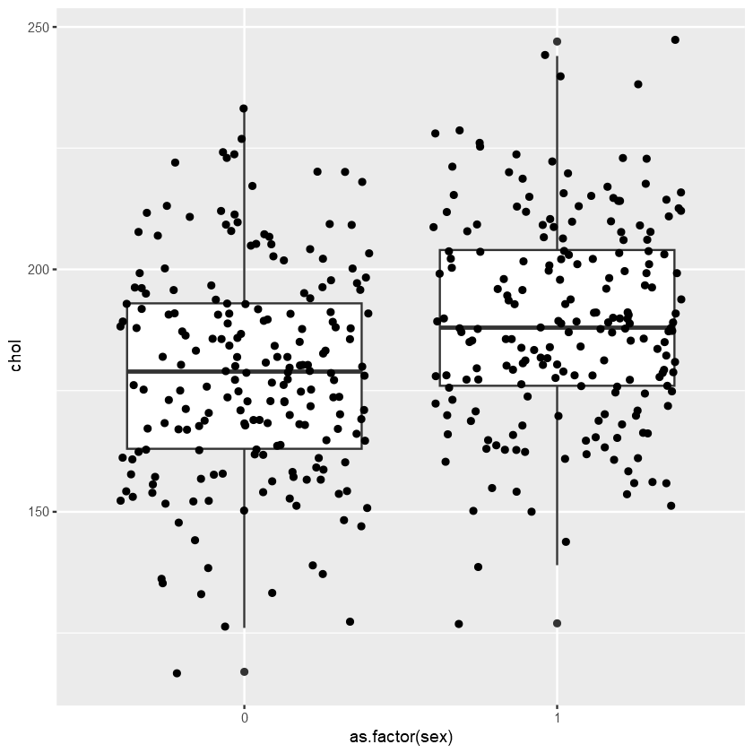

```r
# Make a boxplot of cholesterol grouped by sex
# 1. Data
ggplot(cholesterol) +
    # 2. Aesthetics
    aes(x = as.factor(sex), y = chol) +
    # 4. Geoms
    geom_boxplot() +
    geom_jitter()
```

### 3.4.1 Conditions for performing the ANCOVA

Before moving on, there are some conditions we should look into before beginning our ANCOVA:

1. **Linearity** between the covariate and the outcome variable at *each level* of the grouping variable. In this case we are referring to cholesterol (outcome) versus age (covariate) when grouped by sex.
2. **Homogeneity** of regression slopes. This assumes no interaction between the independent variable and covariate. In other words, the b coefficients must be equal amongst all sub-groups.
3. The residuals of the outcome variable should be approximately **normally distributed**.
4. **Homoscedasticity**. Remember we want homogeneous residual variance for all groups.
5. No significant **outliers** in the group.

### 3.4.1.1 Check your linearity and homogeneity condition

We've been looking at this data quite a bit, but let's remind ourselves that there remains linearity between age and cholesterol when grouping by sex. We can generate a scatterplot with regression lines to help us visually assess the situation.

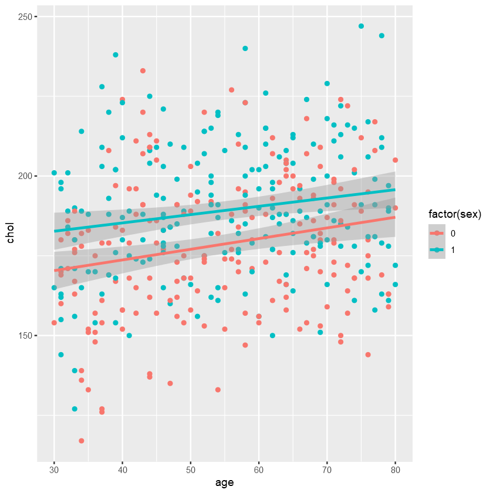

```r
# Plot age vs cholesterol and group by sex
ggplot(cholesterol) +
    aes(x = age, y= chol, color = factor(sex)) +
    geom_point() +
    stat_smooth(method = "lm")
```

From above, our visual inspection of the scatterplot suggests that we still see a trend between increasing age and cholesterol even when grouping by sex. Sex doesn't change the relationship between age and cholesterol as these lines are almost parallel ie *no interaction*. We can also see females when compared to males, on average, appear to have a higher mean cholesterol score with increasing age.

### 3.4.1.2 Check for homogeneity of the regression slopes with an `aov()`

For simplicty, we can build a model based on an interaction between **sex** and **age** using `aov()` and look at the results.

```r
# check for homoegeneity with aov() and interaction between sex and age
summary(aov(chol ~ sex*age, data = cholesterol))
```

```
             Df Sum Sq Mean Sq F value   Pr(>F)
sex           1  11709   11709  26.339 4.50e-07 ***
age           1   7317    7317  16.460 5.99e-05 ***
sex:age       1    114     114   0.255    0.614
Residuals   396 176049     445
---
Signif. codes:  0 '***' 0.001 '**' 0.01 '*' 0.05 '.' 0.1 ' ' 1
```

From above, we see that both **sex** and **age** appear to have a significant effect on cholesterol values. This we have already seen in our previous models. We can also see from our interaction test "sex:age" that there is a low F-value and the associated p-value is high so no significant interaction occurs between the two variables. This further confirms homogeneity of the regression slopes.

### 3.4.1.3 `plot()` your models for quick visual assessment

One thing we haven't yet gone over is how to quickly extract and visualized information about your model. It's as simple as using the `plot()` function and providing our model object. Now that we can assume no interaction between our variables in the model, we'll stay with that idea.

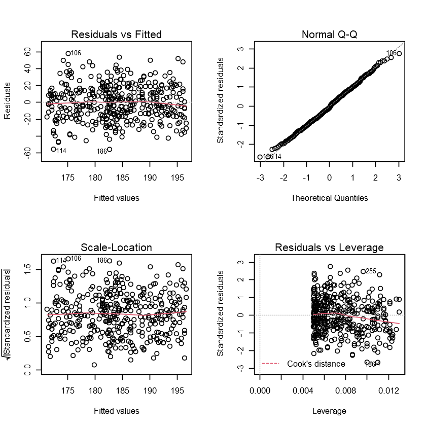

```r
# Use par() to quickly set the plotting area parameters
par(mfrow = c(2,2))

# Plot the model WITHOUT interaction
plot(aov(chol ~ sex + age, data = cholesterol))
```

From above, three of these graphs are the most important.

- **Rule 3 (residual normality)**: The top right is a Q-Q plot of the residuals which looks like it follows a normal distribution
- **Rule 4 (homoscedasticity)**: The top left displays our residuals vs fitted (model) values. The lack of any discernible pattern suggests that there is homogeneity of variance in our residuals.
- **Rule 5 (outliers)**: Finally the bottom right plot of **Residuals vs. Leverage** helps to identify if any particular datapoints have a strong influence on the model. If any points fall outside the dotted line (Cook's distance) their removal from the dataset would strongly influence the coefficients of the model. [These *could* be considered outliers or might suggest you need a different model!](https://www.statology.org/residuals-vs-leverage-plot/)

Let's build a model of `chol` based on non-interactive variables `age` and `sex` using the `lm()` function.

```r
# Make a multiple linear regression with a continuous and categorical variable, without interaction
ageSexFit <- lm(chol ~ age + sex, data = cholesterol)

# Check the results of our model
summary(ageSexFit)
```

```
Call:
lm(formula = chol ~ age + sex, data = cholesterol)

Residuals:
    Min      1Q  Median      3Q     Max
-55.662 -14.482  -1.411  14.682  57.876

Coefficients:
             Estimate Std. Error t value Pr(>|t|)
(Intercept) 162.35445    4.24184  38.275  < 2e-16 ***
age           0.29697    0.07313   4.061 5.89e-05 ***
sex          10.50728    2.10794   4.985 9.29e-07 ***
---
Signif. codes:  0 '***' 0.001 '**' 0.01 '*' 0.05 '.' 0.1 ' ' 1

Residual standard error: 21.06 on 397 degrees of freedom
Multiple R-squared:  0.09748,	Adjusted R-squared:  0.09293
F-statistic: 21.44 on 2 and 397 DF,  p-value: 1.44e-09
```

### 3.4.2 Interpreting our ANCOVA *without* interactions (additive model)

Controlling for sex, mean cholesterol increases by 0.29697 mg/dl for an additional year of age. This is close to the slope for our model of cholesterol alone, 0.31 mg/dl. This does not necessarily mean that the age/cholesterol relationship is the same in males and females; we need to check out the interaction term. There appears to be an increase in mean serum cholesterol of 10.5 mg/dl in females over males. Overall, this model also explain ~9.3 of the variance in cholesterol values.

Let's go back and build an `lm` model of cholesterol that includes interaction between `age` and `sex`.

```r
# Build a new interaction model between cholesterol and age
ageIntSexFit <- lm(chol ~ age * sex, data = cholesterol)

summary(ageIntSexFit)
```

```
Call:
lm(formula = chol ~ age * sex, data = cholesterol)

Residuals:
    Min      1Q  Median      3Q     Max
-56.474 -14.377  -1.215  14.764  58.301

Coefficients:
             Estimate Std. Error t value Pr(>|t|)
(Intercept) 160.31151    5.86268  27.344  < 2e-16 ***
age           0.33460    0.10442   3.204  0.00146 **
sex          14.56271    8.29802   1.755  0.08004 .
age:sex      -0.07399    0.14642  -0.505  0.61361
---
Signif. codes:  0 '***' 0.001 '**' 0.01 '*' 0.05 '.' 0.1 ' ' 1

Residual standard error: 21.08 on 396 degrees of freedom
Multiple R-squared:  0.09806,	Adjusted R-squared:  0.09123
F-statistic: 14.35 on 3 and 396 DF,  p-value: 6.795e-09
```

### 3.4.3 Interpreting our ANCOVA *with* interactions

Males are coded as 0 and females are coded as 1 in this model.

The intercept term is the mean serum cholesterol for MALES at age 0 (160.31 mg/dl). The slope term for age is the difference in mean cholesterol associated with a one year change in age for MALES. The slope for sex (14.56 mg/dl) is the difference in mean cholesterol between males and females at age 0. The interaction term is the difference in the change in mean cholesterol associated with each one year change in age for females compared to males. Sex exerts a small and not statistically significant effect on the age/cholesterol relationship.

### 3.4.4 Compare the results of our many models

Let's compare the results of our models with and without an interaction term.

| ANCOVA Model | Male Intercept | Male slope | Female Intercept | Female Slope |
| --- | --- | --- | --- | --- |
| No Interaction | 162.35 | 0.29 | 172.85 | 0.29 |
| WIth Interaction | 160.31 | 0.33 | 174.87 | 0.26 |

They seem quite similar and we also already know from testing for our conditions, that there is no significant interaction between age and sex. Still, let's confirm by comparing the two models directly.

```r
# anova comparison of the two interaction models
anova(ageSexFit, ageIntSexFit)

# AIC comparison of the two interaction models
AIC(ageSexFit, ageIntSexFit)
```

A anova: 2 × 6

|  | Res.Df <dbl> | RSS <dbl> | Df <dbl> | Sum of Sq <dbl> | F <dbl> | Pr(>F) <dbl> |
| --- | --- | --- | --- | --- | --- | --- |
| 1 | 397 | 176162.3 | NA | NA | NA | NA |
| 2 | 396 | 176048.7 | 1 | 113.5242 | 0.2553587 | 0.613608 |

A data.frame: 2 × 2

|  | df <dbl> | AIC <dbl> |
| --- | --- | --- |
| ageSexFit | 4 | 3578.229 |
| ageIntSexFit | 5 | 3579.971 |

### 3.4.4 Does our ANCOVA model improve on our one-way ANOVA?

In conclusion, adding the interaction term did not change the model significantly. Does our ANCOVA model `ageSexFit` grouping cholesterol values by sex and using age as a covariate improve on our one-way ANOVA model `sexfit` where we predict cholesterol using only sex?

```r
# Compare the two models with anova
anova(sexFit, ageSexFit)

# Use AIC to compare the models
AIC(sexFit, ageSexFit)
```

A anova: 2 × 6

|  | Res.Df <dbl> | RSS <dbl> | Df <dbl> | Sum of Sq <dbl> | F <dbl> | Pr(>F) <dbl> |
| --- | --- | --- | --- | --- | --- | --- |
| 1 | 398 | 183479.7 | NA | NA | NA | NA |
| 2 | 397 | 176162.3 | 1 | 7317.467 | 16.49067 | 5.891828e-05 |

A data.frame: 2 × 2

|  | df <dbl> | AIC <dbl> |
| --- | --- | --- |
| sexFit | 3 | 3592.509 |
| ageSexFit | 4 | 3578.229 |

Indeed the addition of our age covariate does result in a very different model from predicting by sex alone. Furthermore, the addition of age improves on the model based on a number of indicators including the AIC comparison of the models.

**Comprehension Question 3.0.0:** What is the major difference between ANOVA and ANCOVA? Briefly describe how ANCOVA performs an analysis of covariance.

## Comprehension Question 3.0.0 Answer:

# 4.0.0 Review: Models we used today

| We've learned many different models today, or have we? |
| --- |

Before we move on, I want to take a step back and quickly review the models and code we've gone through today. First, with our example dataset, and then more generally. I hope you can see that although conceptually different, getting a handle on the code isn't too bad.

For all of these models we are trying to determine the effect of different variables on cholesterol. The differences are whether we are using:

- continuous data
- categorical data
- a mixture of data types
- and whether there is an interaction (`*`) between our input variables.

| model | categorical | continuous | R code example |
| --- | --- | --- | --- |
| simple linear regression | X | $\checkmark$ | lm(chol ~ age) |
| multiple linear regression | X | $\checkmark\checkmark$ | lm(chol ~ age + BMI) lm(chol ~ age*BMI) |
| one-way analysis of variance (ANOVA) | $\checkmark$ | X | lm(chol ~ as.factor(rs174548)) |
| multi-way analysis of variance (ANOVA) | $\checkmark\checkmark$ | X | lm(chol ~ as.factor(sex) + as.factor(rs174548) lm(chol ~ as.factor(sex))*as.factor(rs174548)) aov(chol ~ as.factor(sex) + as.factor(rs174548) aov(chol ~ as.factor(sex))*as.factor(rs174548)) |
| analysis of covariance (ANCOVA) | $\checkmark$ | $\checkmark$ | lm(chol ~ as.factor(sex) + age) lm(chol ~ as.factor(sex)*age) |

Remember that you can produce ANOVA tables using Type-III sum of squares using the `car::Anova()` function. We have started with models that assume normally distributed errors, but there are other models left unexplored in this lecture.

### 4.0.1 Quick code tables for regression models

In the table below, our R code for each of the models has been generalized. Here, $y$ is our predictor variable, $x$ is a continuous variable, and $f$ is a categorical variable (assumed to be a factor already).

| model | R code |
| --- | --- |
| simple linear regression | lm(y ~ x) |
| multiple linear regression | lm(y ~ x + I(x^2) lm(y ~ x<sub>1</sub> + x<sub>2</sub>) lm(y ~ x<sub>1</sub>*x<sub>2</sub>) |
| one-way analysis of variance (ANOVA) | lm(y ~ f) |
| multi-way analysis of variance (ANOVA) | lm(y ~ f<sub>1</sub> + f<sub>2</sub>) lm(y ~ f<sub>1</sub>*f<sub>2</sub>) |
| analysis of covariance (ANCOVA) | lm(y ~ f + x) lm(y ~ f*x) |

You need not memorize any of these charts - you may just want to use them to orient yourself in the future. Much of the R code seems the same whether you are doing multiple linear regression, ANOVA or ANCOVA, so it is good to have a reference point.

### 4.0.2 Linear models as a "make the appropriate choice" adventure

A non-exhaustive but fair summary of what we've discussed today. This generally applies to the small corner of general linear models we've covered today.

[output not shown]